# Data Science and AI Tools for Beginners

**Andrew Yim**(2026-09-30)

# The problem to solve

- You have a task that can be *automated with code*
- You want to know how an *AI assistant* can help

## Why automation with code?

- **Repetitive tasks** can be automated to *save time and reduce errors*
- **Scalability**: Automation allows *scaling out in parallel* if needed
- **Scheduled tasks** can be automated to run at specific times *without human attention*
- **Judgment-based tasks** can be automated with *AI acting as your surrogate*
- **Complex tasks** can be automated by *building workflows incrementally*, with each step validated before moving on to the next
- **Reproducibility**: Automated workflows can be *reproduced exactly*, verified by others, and shared with others/the future self

**Code enables** **knowledge accumulation and transfer**

## Automation with code: Examples

- **Structured/Unstructured data collection**, such as database queries, web scraping
- **Summarization/Categorization** with large language models (LLMs) via API calls
- **Document/Image processing**, such as text extraction, color correction, watermarking

# No programming Experience?

- *“I don’t know how to code!”*

[figure not shown]

  - **English** is the new programming language
- Your productivity is only limited by **how clear**
  - you *explain your problem* to AI
  - you *specify your requirements* for the solution
- A capable AI assistant will fill in the gaps in between
  - but you need to **guide** it with clear instructions and feedback

## GitHub ecosystem

[figure not shown]

## Why GitHub, GitHub Codespace, and GitHub Copilot?

- **GitHub** provides spaces to *store, manage, and share code* with others
  - Code files of a project are organized in a *repository* (*repo*) with *version control* to track changes
- GitHub **Codespace** (built on **VS Code**) provides a *ready-to-use development environment* in the cloud, without requiring the setup of VS Code in a local machine
- GitHub **Copilot** is an *AI assistant* sitting inside Codespace/VS Code to
  - answer your questions (*Ask* mode)
  - formulate plans to implement your ideas (*Plan* mode)
  - act as your agent to execute the plans to generate code and verify the results (*Agent* mode)

## Branches of a GitHub repo

- **Main branch**: The default branch of a repo, where the *stable version* of the code is stored
- **Feature/Development branch**: A branch created to develop a new feature or experiment with code changes, without affecting the main branch

# If AI can formulate and execute plans for me, …

- Why do I need to learn coding?

[figure not shown]

## Why still learn coding?

- As of *today*, the AI models most of us can afford for heavy, daily use are *still not smart enough* to always deliver the required results without guidance
- The more you know, the better you can **stay on top** of everything
  - Otherwise, you won’t notice any **wrong direction** AI might take you to — and won’t be able to correct it in time

## How useful is AI?

- Easy to use AI to deliver a *working solution*
  - Especially useful when
    - you don’t know how to code, or
    - you don’t have any precise requirements for the solution
- Not so easy to get AI to deliver a *solution exactly as you want*
  - Knowing how to give *directional guidance* while leveraging AI’s capability to *fill in the gaps* is key to success

## Why version control is important

- Version control (by **Git**) tracks changes to your code over time
- To **commit** changes (i.e., save them for the long term), you must give a *commit message* to describe the changes made
- This sets a checkpoint that allows *reverting to a previous version* of the code,
  - protecting you from losing the original work after *failed experimentation* or accidental deletion by you or your **AI assistant**

# marimo

- [**marimo**](https://marimo.io/) is a **reactive** Python notebook
  - automatically **runs dependent cells** whenever a cell is run or a UI element is interacted with,
    - keeping code and outputs consistent.
- Especially **friendly to beginners** due to:
  - using **`uv`** to handle packages installation and environment setup **under the hood**

## Pain points of using Python

- The power of Python comes from its **ecosystem of libraries** (aka. packages) that provide pre-built functions for various tasks
  - Packages are often developed by different authors, and may have **different versions** with **incompatible dependencies**, let alone the **Python version** itself
- Traditional installation methods use `pip` or `conda` to install packages, which can lead to **dependency conflicts** and **version mismatches**, especially when multiple projects require different versions of the same package
  - The solution is to use **virtual environments** to isolate dependencies for each project, but this can be cumbersome and error-prone for beginners
  - The maintenance of virtual environments results in duplicated packages and **wasted disk space**, especially when multiple projects share similar dependencies

## `uv` as the rescue

- ensure the correct versions of packages are installed and used
- avoid duplicated installations and wasted disk space by
  - using **symlinks** to point to the shared packages instead of copying them

## Why marimo?

- Other often praised features include:
  - Built-in interactive elements
  - Directed Acyclic Graph (DAG)-based
    - handles **code execution order** automatically, so you don’t have to worry about the order of code cells
  - Dual-mode execution
    - can be run in an **interactive** interface and in a **shell**, bridging the gap between exploratory **notebook-based** and production-ready **script-based** workflows
  - Useful details provided in the **notebook interface** than Jupyter notebook when exploring data with pandas

## Marimo Don’ts

- **Do NOT re-define** an object **in another cell**
  - Variable names and function names must not be re-used
  - Or, will cause an error like this:

This cell wasn’t run because it has errors

This cell redefines variables from other cells.

**SP500_data** was also defined by:

cell-75

Why can’t I redefine variables? marimo requires that each variable is defined in just one cell. This constraint **enables** reactive and reproducible execution, **arbitrary cell reordering**, seamless UI elements, execution as a script, and more.

Try merging this cell with the mentioned cells or wrapping it in a function. Alternatively, *rename variables to make them private to this cell by **prefixing them with an underscore** (e.g. **_SP500_data**)*.

Learn more at our docs ↗: https://docs.marimo.io/guides/reactivity/#multiple-definition-error

## `.devcontainer` in Codespace

- For marimo to be beginner-friendly and **work out of the box**,
  - marimo and its VS Code extension must be preinstalled in a Codespace
- The magic comes from configuration files in the **`.devcontainer` folder**,
  - which specify the packages and extensions to install and other settings for the Codespace environment

# Code examples (in marimo)

- Unstructured data collection & Document processing

## Unstructured vs structured data

- **Structured** data
  - follows a consistent pattern and thus can be organized in a fixed format,
    - referred to as a **schema** that defines each field’s data type  
      (e.g., integer, text string, double[-precision]/floating-point, date, etc)
  - Example:

| ID | Name | Weight (kg) | Email | Join_Date |
| --- | --- | --- | --- | --- |
| 1324 | John D | 76.1 | john@email.com | 2024-01-01 |
| 2846 | Mary S | 65.5 | mary@email.com | 2024-01-15 |

- **Unstructured** data
  - is inconvenient to organize into a schema, e.g.,
    - Instagram posts - can **vary in the number** of images
    - company reports - can **differ substantially in length**

## Application

- Collecting **sustainability reports** from **company websites**
  - What are the **challenges** (and **solutions**)?

## Human verification triggered by bot detection

- blocks access to a website completely

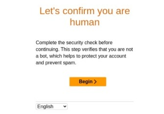

## Cookies popup

- blocks access to the information on a webpage

[figure not shown]

## Other challenges

- Location of target data
  - often **unknown in advance**
- Downloading multiple data files
  - a tedious task that may lead to **omissions** if done manually
- Extracting texts from pdf files for analysis
  - might need to use an **optical character recognition** (**OCR**) approach if a file is **not** text-searchable

# Let’s dive in

- marimo notebooks in [**Workshop repo**](https://github.com/DrAYim/TrainingWorkshop)
  - `1acceptNstoreCookies.py`
  - `2collect_urls.py`
  - `3DLnExtract_OCR.py`

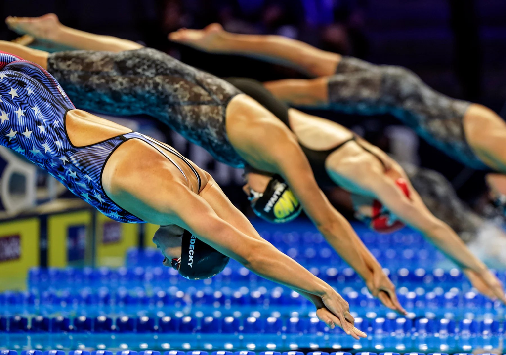

## Overview of the marimo notebooks

- `1acceptNstoreCookies.py`
  - bypasses **bot detection** by a target website
  - handles any **cookie consent banners** that appear  
    (the pop-ups asking you to accept or reject cookies)
  - saves the resulting **cookies** and **local storage** so that later scripts can reuse them
  - collects the **list of URLs** found on the website’s landing page
- May be executed with the **terminal command**:
  - `python3 1acceptNstoreCookies.py`

## 1a. Avoid Bot Detection

- Define settings
  - website to visit, topics to filter URLs by
- Launch a browser (**Playwright** / Chromium)
  - CONTEXT 1 — no evasion:
    - Open a page with no user agent → gets blocked by the website
    - Take screenshot → `screenshot_BotDetected.png`  
      (**confirms the block is real**)
  - CONTEXT 2 — evasion:
    - Set a realistic user agent string and use tricks to hide automation flags **as though** the browser was used by **a human**
      - Open a fresh page → website now loads correctly

## 1b. Accept & Store Cookies

- - CONTEXT 2 — evasion (cont’d):
    - **cookie banner visible** → `screenshot_CookiesPopup.png`
      - Click the “Accept All” button on the cookie banner
    - **banner gone** → `screenshot_CookiesAccepted.png`
      - Extract all URLs from the **landing page** → **`urls_raw.csv`**
      - **Filter** URLs **by topic keywords** → **`urls_filtered.csv`**
      - Save browser cookies & local storage  
        → **`cookies.json`**, **`localStorage.json`**

## Overview of the marimo notebooks (cont’d)

- `2collect_urls.py`
  - crawls a website starting from a set of **seed URLs**
  - follows links up to a configurable **depth**
  - collects all URLs matching specified **keywords** (e.g., sustainability, ESG)
- May be executed with the **terminal command**:
  - `python3 2collect_urls.py`

## 2a. Webcrawling to collect URLs

- Define settings
  - website to crawl
    - only URLs sharing the **highest two-level domain** will be visited  
      (e.g., [‘siemens’, ‘com’])
  - keywords to look for, **how deep** to follow links
  - **maximum run time** to avoid webcrawling indefinitely
- Read candidate URLs from **`urls_filtered.csv`** (previously saved)
  - Remove URLs with **redundant sub-paths** → **`seedURLs.csv`**
    - e.g., `/sustainability/reports/2023` is nested inside `/sustainability/`
  - Load saved browser **cookies** and **local storage**  
    (so the crawler looks like a real user)

## 2b. Webcrawling to collect URLs

- Launch a browser (**Playwright** / Chromium)
  - For each **seed URL**:
    - Visit the page
    - **Collect all links** on that page
    - For each link that matches a keyword and is **valid for visit** (e.g., not a `mailto:` or `pdf`)
      - Visit that page and repeat **recursively** up to the **allowed depth**
- Save all URLs discovered → **`allURLs.csv`**  
  (and **`allURLs_df.csv`** with Filename and Extension columns)
  - Save PDF links only → **`pdfURLs.csv`**
  - Save PDFs matching topics → **`pdfscreenedURLs.csv`**
  - Save pages actually visited → **`visitedURLs.csv`**
    - Will not be visited again in future runs of the crawler

## Overview of the marimo notebooks (cont’d)

- `3DLnExtract_OCR.py` automates a PDF data collection pipeline:
  1. **Download** — fetch PDF sustainability reports from a list of screened URLs
  2. **Analyse** — count occurrences of user-defined keywords on each page of the PDFs
  3. **Extract** — save pages with the keywords as individual single-page PDFs

## 3a. Download and Extract Relevant Pages

- Define settings
  - **year** to target, **keywords** to search for in PDFs
  - fraction of reports to download (for demo purpose)
- Create output folders
  - `docArchive/DLdocs/` (for downloaded PDFs)
  - `docArchive/pagesExtracted/` (for extracted pages)
- Read the screened PDF URL list from **`pdfscreenedURLs.csv`** (previously saved)
  - Keep only the URLs containing the target year (e.g. `2019`)
  - Load saved browser **cookies** (so the downloader looks like a real user)

## 3b. Download and Extract Relevant Pages

- For each URL in the filtered list (up to the chosen fraction):
  - Check the **download ledger `df_DL.csv`** → Skip if already downloaded
  - Otherwise, download and save the PDF to **`DLdocs/`**
    - **Update** the download ledger `df_DL.csv` accordingly
  - Check internal **page numbering** of the downloaded PDF
    - if broken → fix it after backing up the original to **`bad/`** subfolder
  - Extract text from the PDF based on PDF type:
    - if **text-searchable** → use `PyMuPDF`
    - if scanned → use **OCR** tools to recognize text
  - **Count occurrences** of the keywords page-by-page
    - Record and save `[page number, keyword count]` pairs in `df_DL.csv`
- For each page on the list of `[page number, keyword count]` pairs:
  - Extract and save the page to **`pagesExtracted/`**

# Getting AI assistance

## Inline autocompletion

- Inline suggestions for **code completion**, documentation, and code snippets
  - Also, useful for **developing slides** and **writing documents** (e.g., in Quarto/Markdown) in editors
- To **reject** an inline suggestion,
  - pressing **`Esc`** to express *“Leave me alone for now”*

## Ask vs. Plan mode

- **Ask mode**: Q&A conversation in a chatbox — like most people’s first experience with chatGPT
- **Plan mode**: Describe a problem for AI to formulate a solution plan,
  - which you can *review and agree on **before implementation***
- Downsides of **using Plan mode for an Ask-mode question**
  - **Wrong output shape** — producing a plan when you just want a direct explanation
  - **More overhead** (thorough upfront investigation of the codebase)
    - wasted effort when you just want an answer
  - **Nudging toward `Start Implementation`**
    - even when you don’t intend to make code changes

## Plan vs. Agent mode

- Under **Plan mode**, the AI assistant is **not allowed to change** any code
- **Agent mode**: Can **autonomously generate/alter/delete** code as needed to achieve the goal specified by you (or in the agreed plan)
  - Depending on the configuration, may still need your permissions on actions with **significant consequences**,
    - e.g., using certain tools such as **bash** commands, accessing the internet, or sending emails

# Importance of context window size

- The **context window** size determines the amount of information that can be considered at once by an AI model
- The invisible **system prompt** for guiding the model’s behavior and responses can take up a significant portion of the context window,
  - leaving less space for user input (**prompts**) and model output (**responses**)
- A larger context window allows the model to understand and generate more *coherent and contextually relevant responses*, especially for complex tasks involving long documents or conversations.
- Models with smaller context windows handle context exhaustion through **compression/compaction** (i.e., truncating or summarizing the input)
  - May lead to loss of important input information and less accurate output

## Rules of thumb

- Avoid long conversations that exceed a model’s context window
- At least *1M tokens* context window is necessary for a series of related complex tasks emerging from a long conversation
- *At least 200K tokens* context window is needed for serious work other than simple tasks
- If *two rounds* of prompt-and-response aren’t getting you closer to your goal (e.g., fixing a bug),
  - consider switching to a more capable (likely more expensive) model but *more expensive models are not necessarily better*
- Experiment with different models to find out which ones work well for particular tasks and requirements

## OpenCode / GitHub Copilot / Codex / Claude Code

- Why [**OpenCode**](https://opencode.ai/)?
  - **Open-source** project avoiding vendor lock-in
    - unlike [**Claude Code**](https://github.com/anthropics/claude-code#get-started) and **GitHub Copilot**, which are closed-source
  - Similarly **wide support for LLM providers** as GitHub Copilot
    - unlike [**Codex**](https://github.com/openai/codex#quickstart), which sends some tool calls in OpenAI-specific formats — non-OpenAI LLMs don’t always work reliably even with translation
  - **Comparable harness performance** to other agents for third-party LLMs
- [OpenCode **Zen**](https://opencode.ai/zen) has a few free models with generous **rate limits** and context window sizes for users to get started without paying anything
  - e.g., *MiMo V2.5 Free* with 200K tokens context window
- [OpenCode **Go**](https://opencode.ai/go) offers a low-cost monthly subscription plan with a range of serious models suitable for more complex tasks
  - e.g., *DeepSeek V4.1 Flash* with 1M tokens context window

# LLM access via API

- Minimal example: `4MinExample_LLMapi.py`
  - input data: `4MinExample_Notes.parquet`
  - output results: `4MinExample_Coded.parquet`

# Power of GPU acceleration

## Lightning.ai

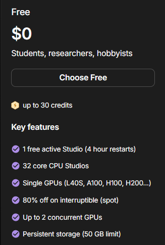

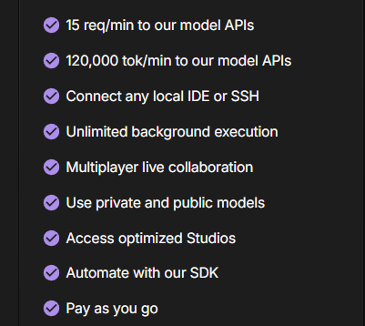

- How much can a GPU accelerate?
  - Let’s look at an application example with **natural language processing** (**NLP**)

## Bigram cloud

- *Word cloud*
  - visual representation of text data with
    - each word’s **size** indicating its **frequency**/**importance**
  - *Bigram cloud* extends the concept to pairs of words (*bigrams*) instead of single words
- Application example:
  - What **risk factors** are mentioned in *Item 1A* of *Magnificent 7*’s 10-K filings (2015 vs. 2025)?
    - `AAPLE`, `MSFT`, `GOOGL`, `AMZN`, `NVDA`, `META`, and `TSLA`

## Identifying bigrams in text

- **Stop** words (e.g., “of”, “the”, “is”, “and”)
  - removed to focus on more meaningful content
- Older approaches focused on **stemmed** words
  - reduced to their *root form*  
    (e.g., “vis” for vision, visions, visionary, and visibility)
- Newer approaches use **lemmatized** words
  - reduced to their *base form*  
    (e.g., “vision” for vision and visions; “visionary” for visionary)
- Lemmatization is computationally intensive, which benefits greatly from **GPU acceleration**

## Studio on Lightning.ai

- **Studio** in Organization on *Lightning.ai*
  - is like **Codespace** on GitHub
- See the shared Studio template: [**BigramCloud_GPUorCPU**](https://lightning.ai/tlyim-1city-org/templates/bigramcloud-gpuorcpu~01m3m2wf6nq9gw6ytegz6ddtrf)

# Strengths of R ecosystem

## R syntax

- Often more *concise* and *expressive* for data manipulation and analysis tasks

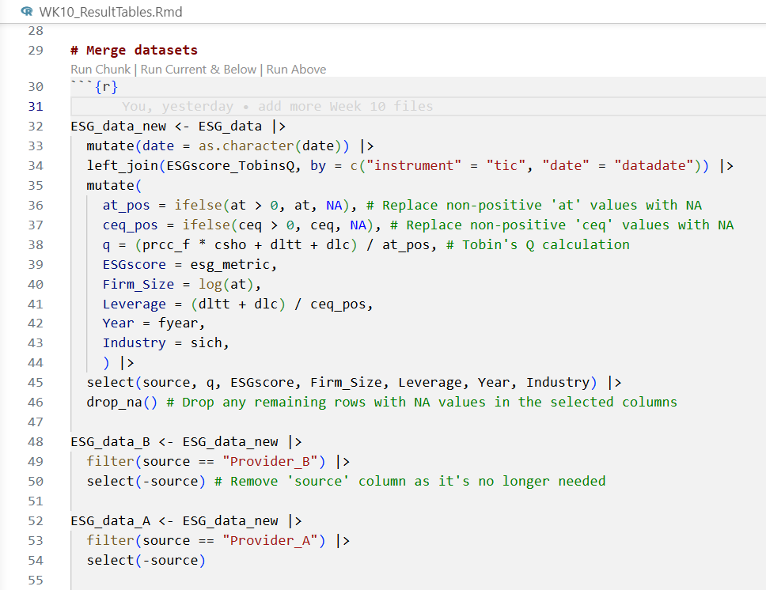

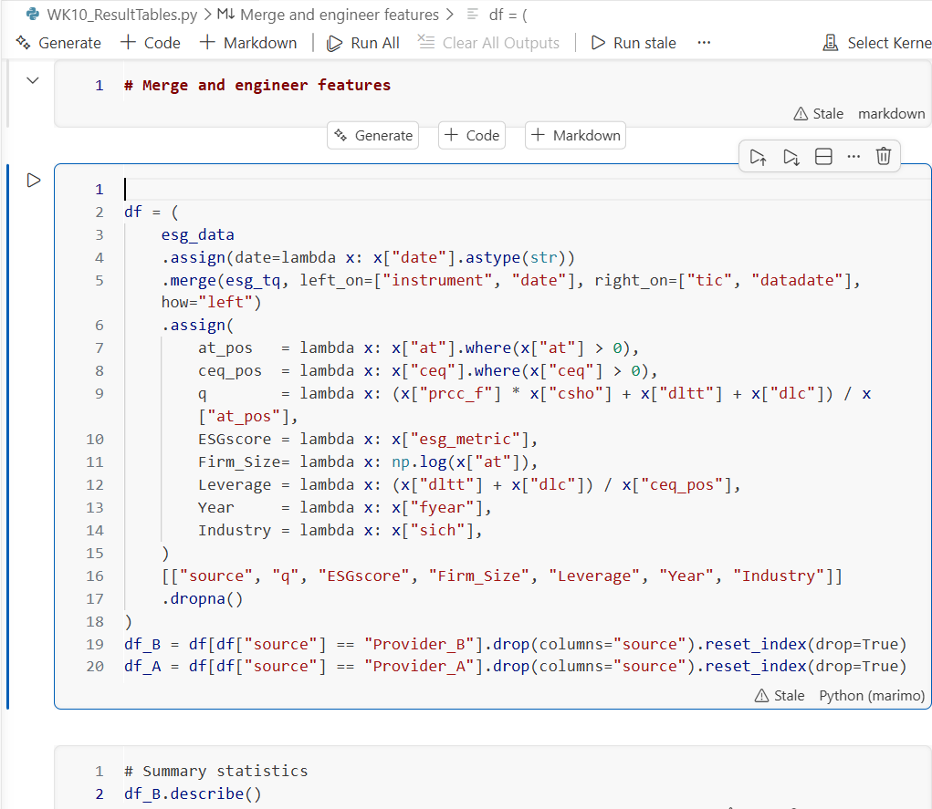

## Rmardown notebooks

- **Plain-text** files
  - easy to version-control
  - readable and editable even *on the go with only a phone*
- Structured in **JSON** format, *Jupyter* notebooks are
  - difficult to version-control effectively
  - **not** as *human-readable* or *edit-friendly*  
    outside of the notebook interface
    - Similarly for *marimo* notebooks, despite being Python scripts (in plain text)
  - Next slide shows the **source code structures** of Jupyter and marimo notebooks

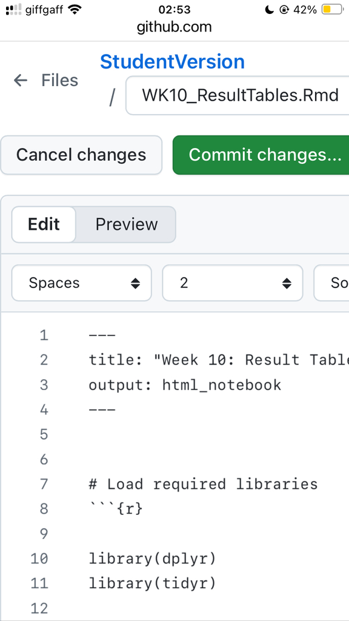

## Unlike Jupyter/marimo notebooks

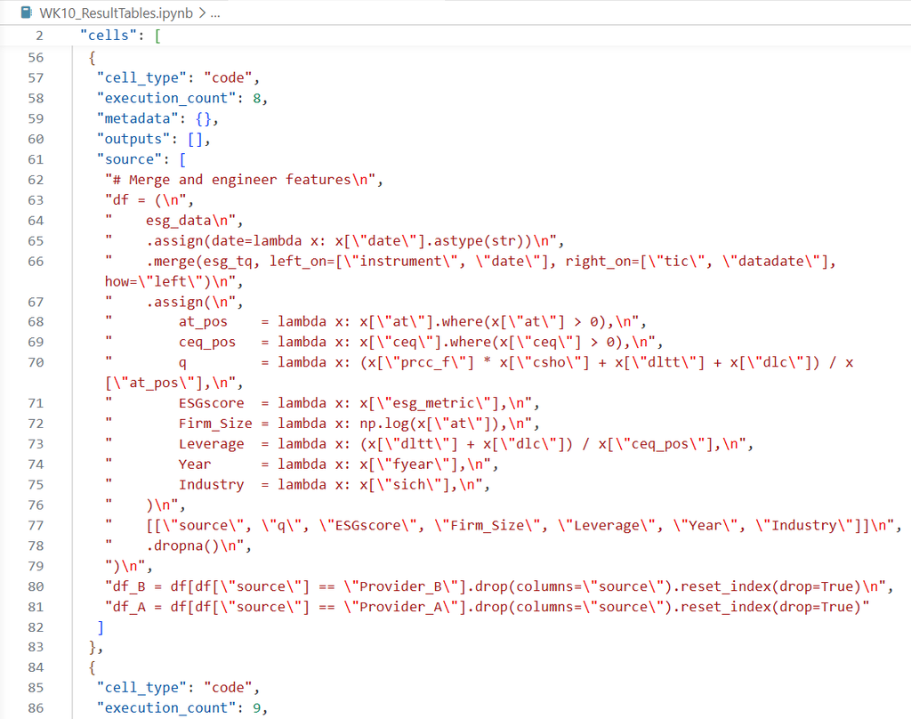

Jupyter

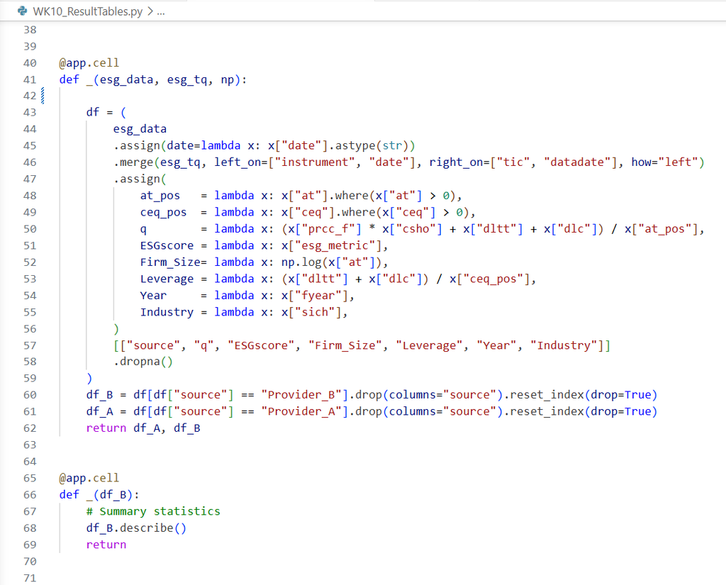

marimo

## Global line number reference

- Jupyter notebooks (and marimo in the notebook interface) **cannot show globally unique line numbers** for the entire notebook,
  - hard to reference specific code lines for **debugging** and documentation
- Not a problem for Rmarkdown notebooks as plain-text files

## Statistical/Econometric analysis

- Packages *specialized* for statistical analysis and econometrics are more likely to be available in R than Python
- For example,
  - *difference-in-differences* (**DiD**) analysis is an important methodology for measuring **causal effects**
  - This [DiD](https://asjadnaqvi.GitHub.io/DiD/) website maintains a comprehensive list of packages for DiD analysis:
    - [16 packages in **R**](https://asjadnaqvi.GitHub.io/DiD/docs/02_R/) vs. [11 in **Python**](https://asjadnaqvi.GitHub.io/DiD/docs/03_python/)

# Expanding Your DS Toolkit

- No single tool solves every problem
  - Understanding the “right tool for the job” is a key skill
- The landscape of Data Science and AI **changes rapidly**
  - Knowing where to find resources is essential for continuous **self-learning and exploration**
- For example,
  - see the newsletter `The Batch` and courses on [DeepLearning.AI](https://www.deeplearning.ai/)
  - also, [AlphaSignal](https://alphasignal.ai)’s daily newsletter on AI, machine learning and cutting-edge language models

# Open-source packages on GitHub

- Powerful packages are freely available on GitHub
  - The challenge: Buried among numerous **poorly maintained/poorly documented** packages on GitHub

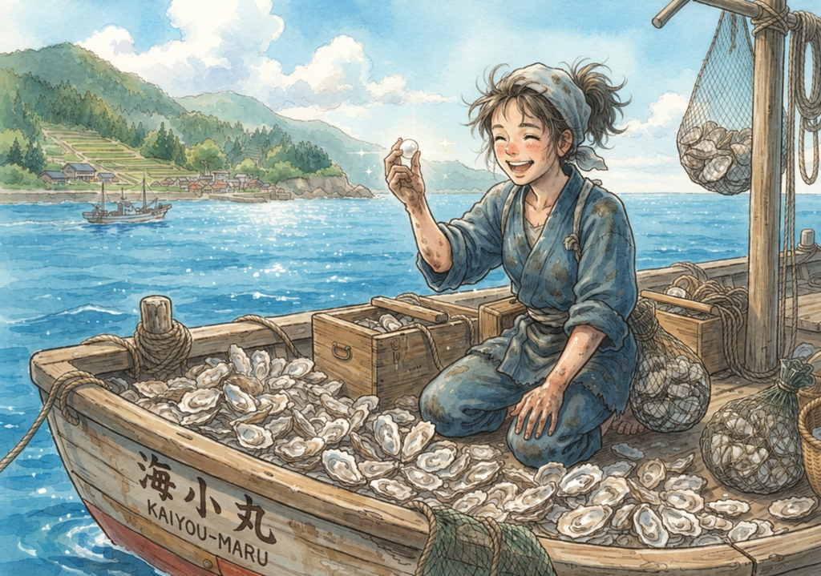

## Adopting Open-source Resources

- **Availability** of open-source packages / data?
  - free vs. freemium vs. paid
- **Reliance** considerations:
  - Abandoned projects?
  - **Organizational backing** (e.g., [polars](https://GitHub.com/pola-rs))  
    vs. Individual developer
  - **Active development**:
    - Last commit
    - Watch | Custom | Releases, Issues, Security alerts

## Adopting Open-source Resources

- Reliance considerations (cont’d):
  - **Maintenance** commitment:
    - Issues tab: Open vs. Closed
  - Usefulness
    - Stars, Used by, Contributors
    - [**Star History** graph](https://GitHub.com/star-history/star-history), [GitHub **Trending ranking**](https://trendshift.io)
  - **Documentation** quality
    - README, docs/doc, Vignettes, Wiki, Website

# Polars vs. Pandas

- Pandas requires RAM to be **at least 2 times** of the dataset size to work
- **Polars** is
  - **memory-efficient** due to various approaches, including
    - **Streaming:** natively process data in optimized batches or chunks for **big data** (i.e., too big to fit into RAM)
  - built on **Rust** — known for its speed and safety
  - **cross-platform**: including R and various other environments
- Polars achieves high performance through **parallel execution** and
  - **lazy evaluation**
    - e.g., if you load a file with 100 columns but only use 3, Polars reads only those 3 columns into memory  
      (by first analyzing the code to determine which are actually needed)

# The month after this workshop

- Recommendation:
  - *Do not wait* until you have a serious task/project to start using AI
  - Simply keep on integrating AI into your workflow on a *daily basis*
    - e.g., start a low-stake toy project that would not matter even if it fails
- Up-to-date information you learned today can *become obsolete in a few months*
- Only when AI has become an *inextricable* part of your workflow will you be
  - motivated to keep up with the latest developments
  - able to accumulate experience and leverage it successfully to solve serious problems

## My toy project

[figure not shown]

# Thank you and best wishes!